# Milestone Report - Data Science Capstone

Attila Toth

25 March 2016

This document aims to present the most recent achievements in the capstone project of Data Science Specialization offered on Coursera by Johns Hopkins University.

The ultimate goal of this project is to create a data application that can predict the next word while typing arbitrary text.

# Goals in Milestone Report

This report aims to explain exploratory analysis and goals for the eventual app and algorithm. It should present the major features of the data, briefly summary of plans for creating the prediction algorithm and Shiny app.

Th following main criteria are to be met: 1. Demonstration of having the data downloaded and successfully loaded into R 2. Creation of a basic report of summary statistics about the data sets 3. Reporting on any interesting findings

# Initialization

This chapter wraps up the initial setup activities, i.e. loading of necessary packages, variables, etc.

```r
# Load libraries

## String operations
library(stringi)
## Graphs
library(ggplot2)
library(gridExtra)
## Text mining
library(quanteda)


# Setup general variables

## Paths of files to be processed
filePathblog <- "final/en_US/en_US.blogs.txt"
filePathnews <- "final/en_US/en_US.news.txt"
filePathtwitter <- "final/en_US/en_US.twitter.txt"
```

# Data Overview

The foundation of the application will be a set of text provided by the course. They are extracts from - blogs, - news, - and twitter.

The application will use various algorithms and techniques to process these texts and provide the most accurate predictions in reasonable time.

First, let’s see very high level features of the provided dataset. (My application will work in English thus I will ignore texts provided in different languages.)

```r
fileblog <- file(filePathblog)
blg <- readLines(con = fileblog, n = -1, warn = FALSE, skipNul = TRUE)
close(fileblog)

filenews <- file(filePathnews)
nws <- readLines(con = filenews, n = -1, warn = FALSE, skipNul = TRUE)
close(filenews)

filetwitter <- file(filePathtwitter)
twttr <- readLines(con = filetwitter, n = -1, warn = FALSE, skipNul = TRUE)
close(filetwitter)

fileStat <- data.frame(col1=c("en_US.blogs.txt",
                              "en_US.news.txt",
                              "en_US.twitter.txt"),
                       col2=c(file.info(filePathblog)$size/1024^2,
                              file.info(filePathnews)$size/1024^2,
                              file.info(filePathtwitter)$size/1024^2),
                       col3=c(length(blg)/1000,
                              length(nws)/1000,
                              length(twttr)/1000),
                       col4=c(sum(stri_count_words(blg))/1000000,
                              sum(stri_count_words(nws))/1000000,
                              sum(stri_count_words(twttr))/1000000),
                       col5=c(sum(nchar(blg))/1000000,
                              sum(nchar(nws))/1000000,
                              sum(nchar(twttr))/1000000
                           )
                       )
colnames(fileStat)  <- c("File Name",
                         "File Size (MB)",
                         "Number of lines (K)",
                         "Number of words (MM)",
                         "Number of characters (MM)")
knitr::kable(fileStat)
```

| File Name | File Size (MB) | Number of lines (K) | Number of words (MM) | Number of characters (MM) |
| --- | --- | --- | --- | --- |
| en_US.blogs.txt | 200.4242 | 899.288 | 37.54180 | 206.8245 |
| en_US.news.txt | 196.2775 | 1010.242 | 34.76230 | 203.2232 |
| en_US.twitter.txt | 159.3641 | 2360.148 | 30.09291 | 162.0962 |

# Exploratory Analyses

This section focuses on the analysis of content of the text. I use techniques of descriptive statistics to reveal the main attributes of documents.

As it is presented in the previous section, the three files contain almost similar amount of information (see file size, number of words and characters) but still my presumption suggests that the three types of documents have significantly different attributes:

- Twitter has been built for short form of communication, limited to 140 characters, that suggest each post (i.e. line in the file) consists of few words, expressing consise opinion in a less formal way
- content of blogs and news might seem similar from technical point of view (i.e. unlimited, continuous paragraphs) but semantically they can differ significantly. News are mainly published by media organizations presenting fact-based statements about our world in proper languange. Blogs, though, can be edited by professional journalists as well (offering quality content like newspaper) but this platform for creating and publishing content is open for anyone thoughout the world. Therefore blogs tend to reflect personal opinion about particular topics being edited by ordinary people that may result in lower quality in content or language.

## Understanding the role of lines

As a starting point I assume that each line represents a single blog post, article or twitter post. I determine the length of each entry by counting characters and words in them. Doing so, the following distributions are revealed:

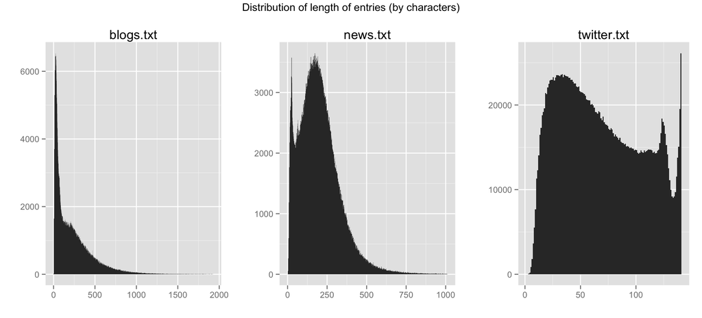

```r
g.blg <- qplot(x=nchar(blg)[-order(nchar(blg),decreasing = TRUE)[1:1000]],
               geom = "histogram",
               main = "blogs.txt",
               ylab="",
               xlab="",
               binwidth=1)
g.nws <- qplot(x=nchar(nws)[-order(nchar(nws),decreasing = TRUE)[1:1000]],
               geom = "histogram",
               main = "news.txt",
               ylab="",
               xlab="",
               binwidth=1)
g.twttr <- qplot(x=nchar(twttr),
                 geom = "histogram",
                 main = "twitter.txt",
                 ylab="",
                 xlab="",
                 binwidth=1)
grid.arrange(g.blg,
             g.nws,
             g.twttr,
             ncol=3,
             top = "Distribution of length of entries (by characters)")
```

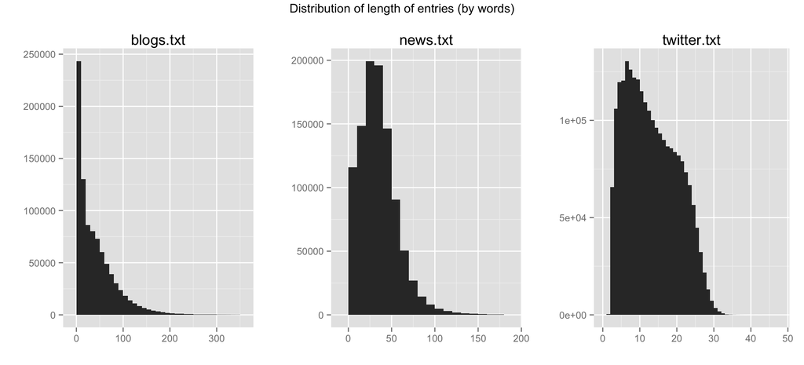

```r
g2.blg <- qplot(x=stri_count_words(blg)[-order(stri_count_words(blg),decreasing = TRUE)[1:1000]],
               geom = "histogram",
               main = "blogs.txt",
               ylab="",
               xlab="",
               binwidth=10)
g2.nws <- qplot(x=stri_count_words(nws)[-order(stri_count_words(nws),decreasing = TRUE)[1:1000]],
               geom = "histogram",
               main = "news.txt",
               ylab="",
               xlab="",
               binwidth=10)
g2.twttr <- qplot(x=stri_count_words(twttr),
                 geom = "histogram",
                 main = "twitter.txt",
                 ylab="",
                 xlab="",
                 binwidth=1)
grid.arrange(g2.blg,
             g2.nws,
             g2.twttr,
             ncol=3,
             top = "Distribution of length of entries (by words)")
```

## Words in text

In this section I focus on the most atomic items of the texts, on the words. In order to analyse them, I need to tokenize (break into words) the documents.

Since the texts I need to work with are relatively big files, for analysis purposes I select a random 1% sample of the original dataset.

```r
set.seed(1234)

blg.rn <- rbinom(n = length(blg), size=1, prob = 0.01)
nws.rn <- rbinom(n = length(nws), size=1, prob = 0.01)
twttr.rn <- rbinom(n = length(twttr), size=1, prob = 0.01)

blg.smpl <- blg[which(blg.rn==1)]
nws.smpl <- nws[which(nws.rn==1)]
twttr.smpl <- twttr[which(twttr.rn==1)]
```

From each sample of the documents I created a single corpus. A corpus is a large and structured set of texts being used to do statistical analysis and hypothesis testing, checking occurrences or validating linguistic rules within a specific language territory. A corpus is designed to be a more or less static container of texts with respect to processing and analysis. This means that the texts in corpus are not designed to be changed internally through (for example) cleaning or pre-processing steps, such as stemming or removing punctuation. Rather, texts can be extracted from the corpus as part of processing, and assigned to new objects, but the idea is that the corpus will remain as an original reference copy so that other analyses – for instance those in which stems and punctuation were required, such as analyzing a reading ease index – can be performed on the same corpus. (via [Wikipedia](https://en.wikipedia.org/wiki/Text_corpus) and [quanteda Quick Start Guide](https://cran.rstudio.com/web/packages/quanteda/vignettes/quickstart.html))

```r
smpl.Corpus <- corpus(c(blg.smpl,nws.smpl,twttr.smpl))
```

In order to perform statistical analyses on the corpus, features need to be extracted from the texts. The object of document-frequency matrix serves this purpose. In `quanted` the `dfm()` function creates this matrix along with tokenization and data cleaning (i.e. conversion to lower case; stemming words; removing numbers, punctuation, separators, stopwords, special characters, etc.)

Also, I converted all words to lower case, kept stopwords and opted stemming out. I believe, removing stopwords would decrease my accuracy, since in the framework of “next word prediction” I can not rule out those ones as they are integrant part of any arbitrary text using for communication. Similarily, stemming words might bring more efficiency in the model but would let space for more inaccuracy by predicting the right word in wrong form.

```r
smpl.dfm <- dfm(smpl.Corpus,
                toLower = TRUE,
                removeNumbers = TRUE,
                removePunct = TRUE,
                removeSeparators = TRUE,
                removeTwitter = FALSE,
                language="english")
```

```
## Creating a dfm from a corpus ...
##    ... indexing 42,821 documents
##    ... tokenizing texts, found 1,028,856 total tokens
##    ... cleaning the tokens, 24702 removed entirely
##    ... summing tokens by document
##    ... indexing 59,377 feature types
##    ... building sparse matrix
##    ... created a 42821 x 59377 sparse dfm
##    ... complete. Elapsed time: 27.587 seconds.
```

Given the document-frequency matrix created, the following main attributes can be observed.

Top 50 words by their frequency of appearance:

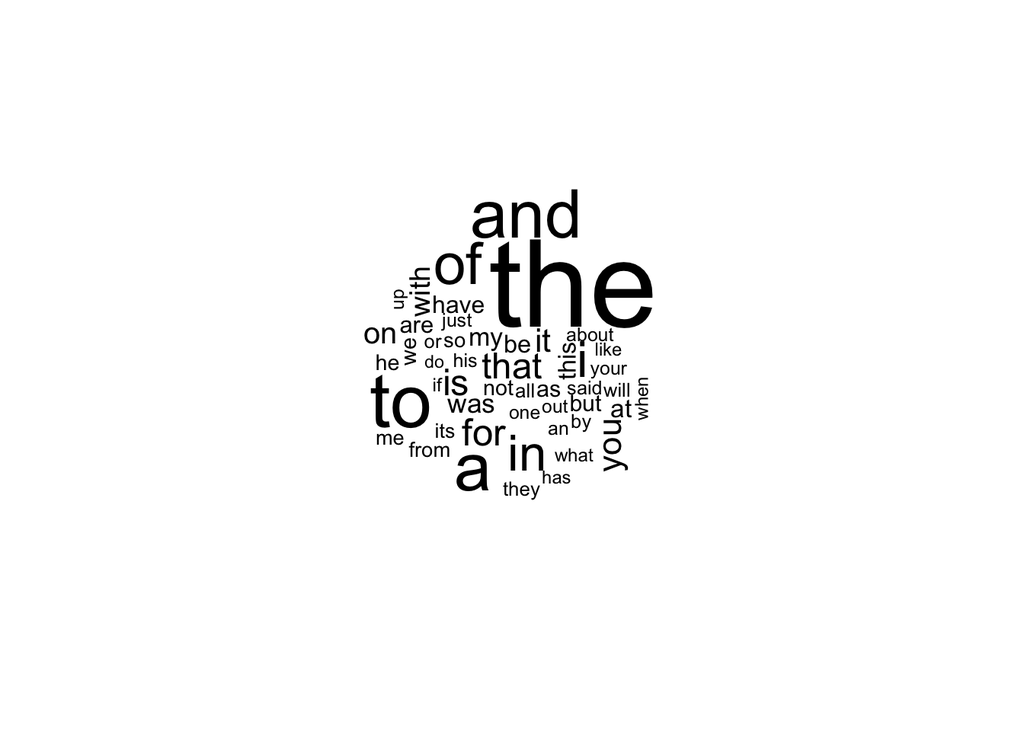

```r
plot(smpl.dfm, max.words = 50, scale = c(5, .5))
```

```r
topfeatures(smpl.dfm, 50)
```

```
##   the    to   and     a    of    in     i   for    is  that   you    it
## 48054 27574 24192 24070 20134 16594 16526 11110 10915 10530  9273  8994
##    on  with   was    my    at    be  this  have   are    as   but    he
##  8015  7159  6445  5993  5799  5544  5460  5331  4994  4889  4804  4266
##    we   not    so  from    me   its   all  they    or    by  will  said
##  4265  4255  3844  3799  3743  3612  3313  3304  3166  3140  3124  3097
##   his  just about    an  your   one    up   out    if  what  when  like
##  3089  3048  2985  2957  2954  2933  2933  2885  2861  2743  2661  2653
##   has    do
##  2622  2476
```

# Future plans

In order to step forward my prediction application, I need to study the words in wider context instead of single words alone. The real prediction question is, by knowing one-two-three already typed word, what, most likely, is the following one? To address this question, I will review certain ngrams in the corpus.